# Preparation

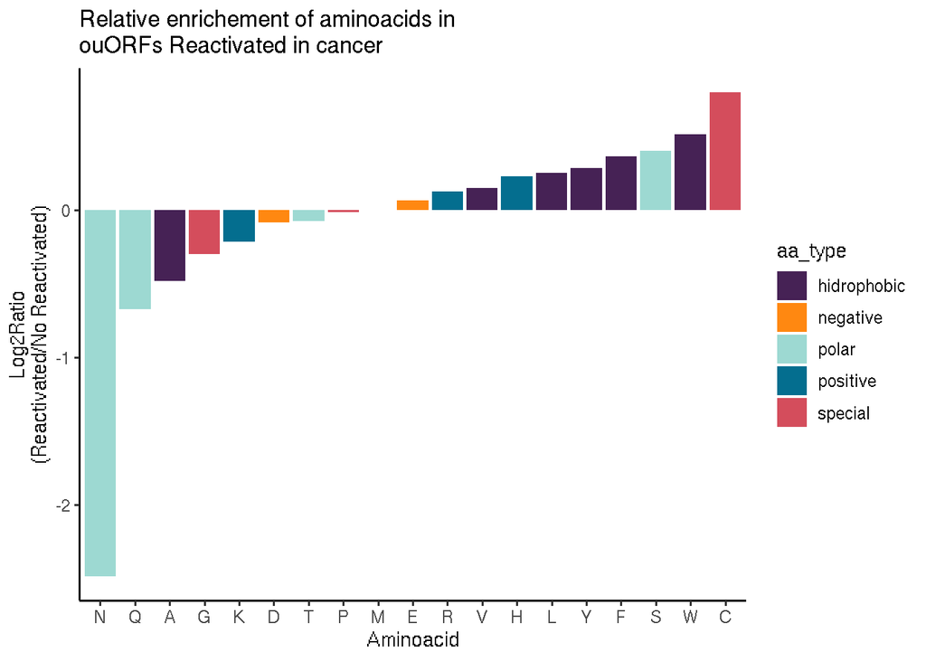

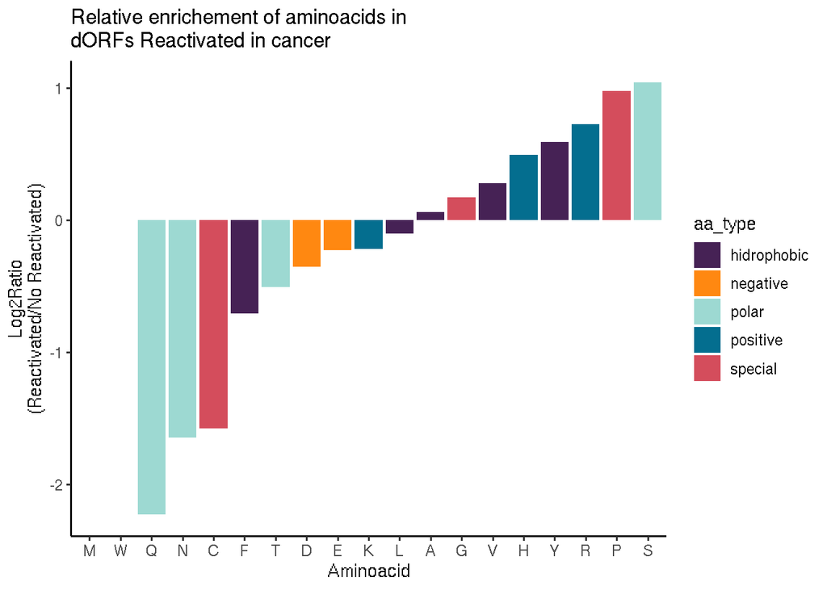

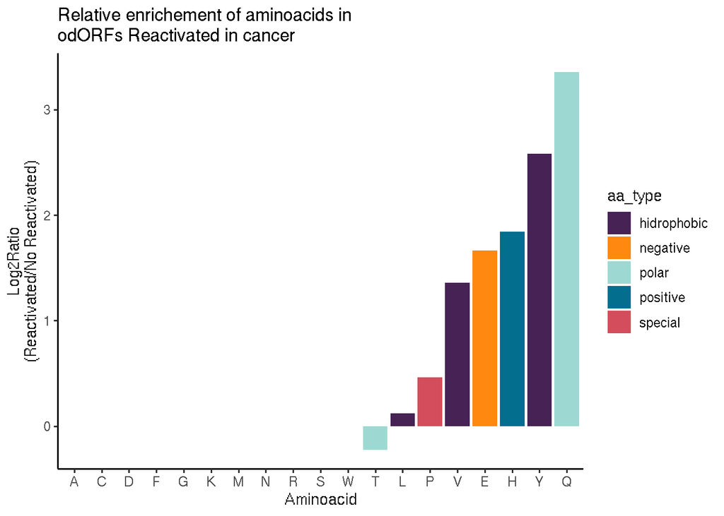

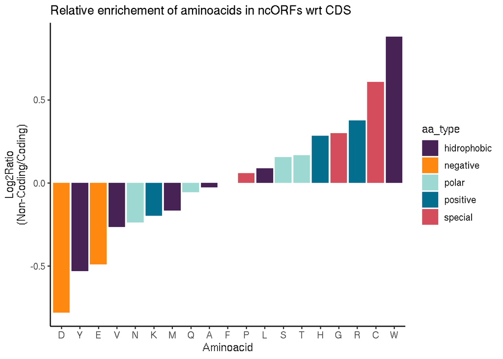

## Tumor-specific antigens contribution

- Cryptic DB
- Beijer et al.
- Erhard et al.
- IEAtlas
- Chong et al.
- Ouspenskaia et al.

```
## [1] "How many ORFs contain at least 1 TSA evidenced by the literature? | Tumor Reactivated"
```

```
## [1] 47
```

```
## [1] "From how many total ORFs?"
```

```
## [1] 189
```

```
## [1] "Proportion = 24.8677248677249%"
```

```
## [1] "How many ORFs contain at least 1 TSA evidenced by the literature? | TestisRestricted"
```

```
## [1] 105
```

```
## [1] "From how many total ORFs?"
```

```
## [1] 868
```

```
## [1] "Proportion = 12.0967741935484%"
```

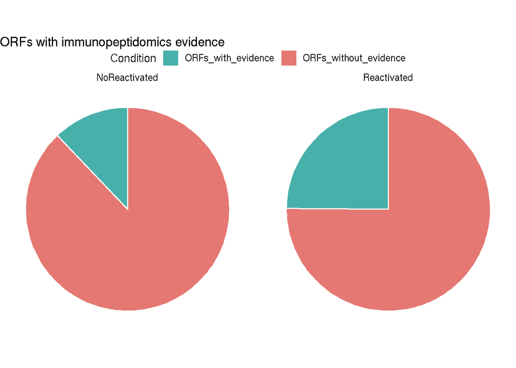

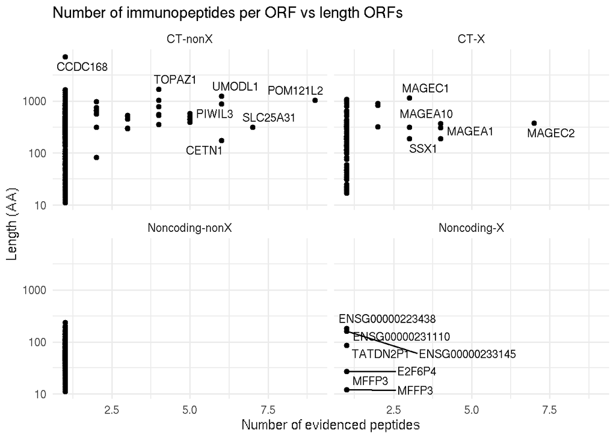

## Selection of TS/TR

### Candidates pan cancer

```
##
##        CT-nonX           CT-X Noncoding-nonX    Noncoding-X
##             54             38             47              1
```

## CTDB

```
## [1] 244
```

```
##
##                  CTDB no
##   CT-nonX          10 44
##   CT-X             26 12
##   Noncoding-nonX    0 47
##   Noncoding-X       0  1
```

## Systematic identification of genes with a cancer-testis expression pattern in 19 cancer types, Wang 2016 Nature Comm

https://www.nature.com/articles/ncomms10499#Sec28

(C2) high-confidence testis-specific non-coding genes: GENCODE-annotated non-coding genes (v19) with SPMGTEx >0.9, SPMHBM >0.9 and SPMNJMU >0.9;

(C3) moderate-confidence testis-specific coding genes: GENCODE-annotated protein-coding genes (v19) with SPMGTEx >0.9 and either SPMHBM >0.9 or SPMNJMU >0.9;

(C4) moderate-confidence testis-specific non-coding genes: GENCODE-annotated non-coding genes (v19) with SPMGTEx >0.9 and either SPMHBM >0.9 or SPMNJMU >0.9;

(C5) low-confidence TSGs: genes with SPMGTEx >0.9 but SPMHBM ≤0.9 and SPMNJMU ≤0.9;

(C6) non-gene-level TSG: genes with SPMGTEx≤0.9.

```
## [1] 140
```

```
##
##        CT-nonX           CT-X Noncoding-nonX    Noncoding-X
##             54             38             47              1
```

```
##
##          CT-nonX CT-X Noncoding-nonX Noncoding-X
##   absent       4    5             27           0
##   C1          40   31              0           0
##   C2           4    1             14           1
##   C3           2    1              0           0
##   C4           0    0              5           0
##   C5           1    0              0           0
##   C6a          1    0              1           0
##   C6b          2    0              0           0
```

```
##
##          CTDB no
##   absent    2 34
##   C1       33 38
##   C2        0 20
##   C3        1  2
##   C4        0  5
##   C5        0  1
##   C6a       0  2
##   C6b       0  2
```

```
##           gene_name coding_noncoding_chr CTDB
## 24        C20orf144              CT-nonX   no
## 65          DCAF8L2                 CT-X   no
## 109          ZNF723              CT-nonX   no
## 110          CT45A1                 CT-X CTDB
## 111         CT45A10                 CT-X   no
## 112          CTAGE6              CT-nonX   no
## 113            TPTE              CT-nonX CTDB
## 114          TEX13C                 CT-X   no
## 116 ENSG00000283599                 CT-X   no
```

```
##           gene_name coding_noncoding_chr CTDB
## 107       LINC02864       Noncoding-nonX   no
## 108        MIR924HG       Noncoding-nonX   no
## 115 ENSG00000283072       Noncoding-nonX   no
## 117 ENSG00000287164       Noncoding-nonX   no
## 118 ENSG00000287861       Noncoding-nonX   no
## 119     XLOC_000211       Noncoding-nonX   no
## 120     XLOC_000429       Noncoding-nonX   no
## 121     XLOC_000487       Noncoding-nonX   no
## 122     XLOC_000496       Noncoding-nonX   no
## 123     XLOC_000806       Noncoding-nonX   no
## 124     XLOC_001054       Noncoding-nonX   no
## 125     XLOC_001101       Noncoding-nonX   no
## 126     XLOC_001195       Noncoding-nonX   no
## 127     XLOC_001255       Noncoding-nonX   no
## 128     XLOC_001350       Noncoding-nonX   no
## 129     XLOC_001470       Noncoding-nonX   no
## 130     XLOC_001518       Noncoding-nonX   no
## 131     XLOC_001619       Noncoding-nonX   no
## 132     XLOC_001633       Noncoding-nonX   no
## 133     XLOC_001654       Noncoding-nonX   no
## 134     XLOC_001691       Noncoding-nonX   no
## 135     XLOC_001784       Noncoding-nonX   no
## 136     XLOC_001828       Noncoding-nonX   no
## 137     XLOC_002024       Noncoding-nonX   no
## 138     XLOC_002098       Noncoding-nonX   no
## 139     XLOC_002210       Noncoding-nonX   no
## 140     XLOC_002273       Noncoding-nonX   no
```

## Chr Position

Bernat Gel & Eduard Serra. (2017). karyoploteR: an R/Bioconductor package to plot customizable genomes displaying arbitrary data. Bioinformatics, 31–33. doi:10.1093/bioinformatics/btx346

```
## [1] 92
```

```
## [1] 48
```

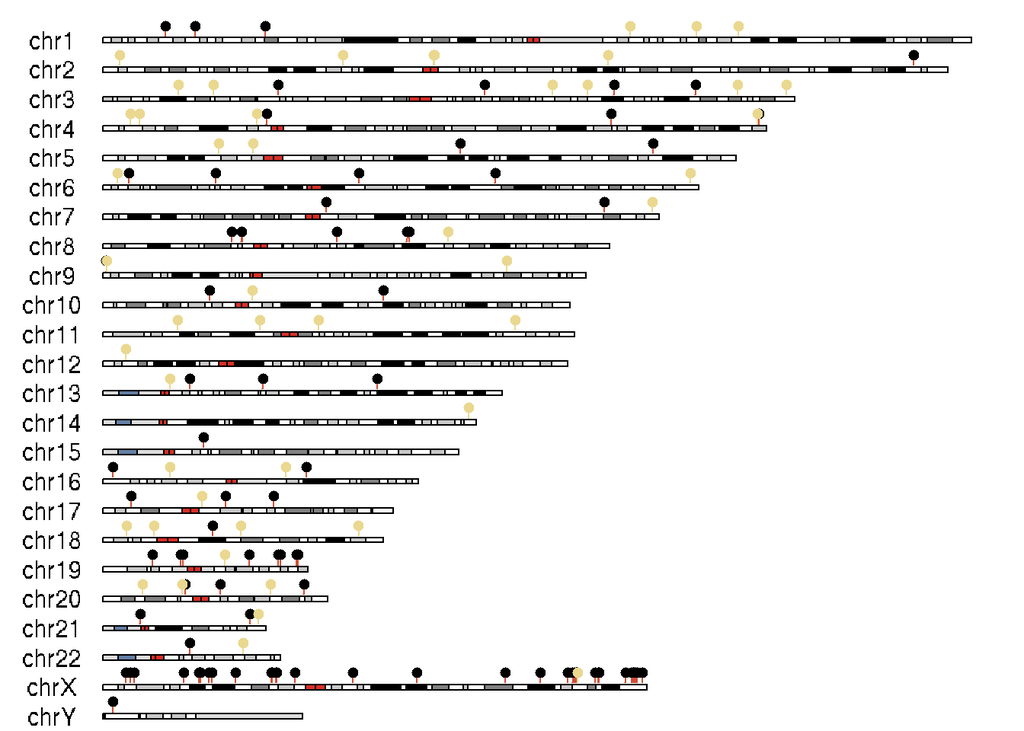

```
## PNG
##   2
```

## Thymus expression

If present in thymus, not reexpressed but mutations

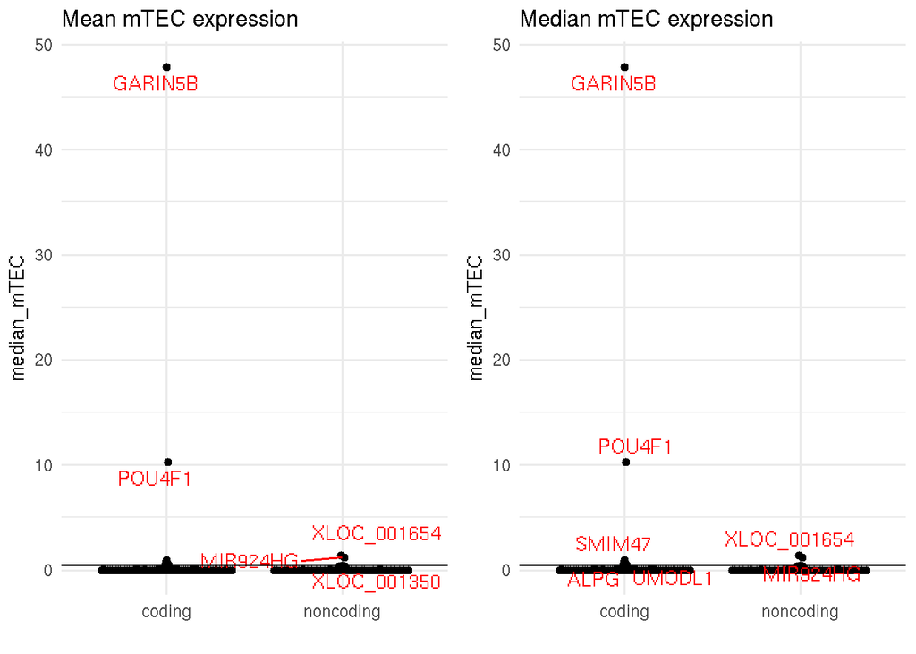

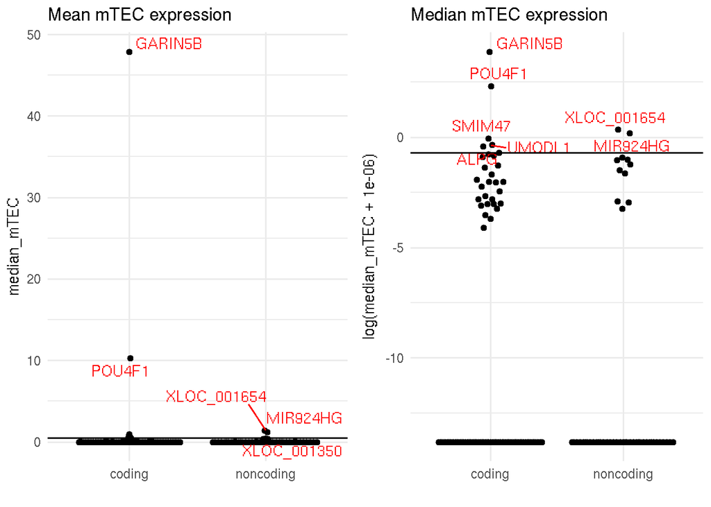

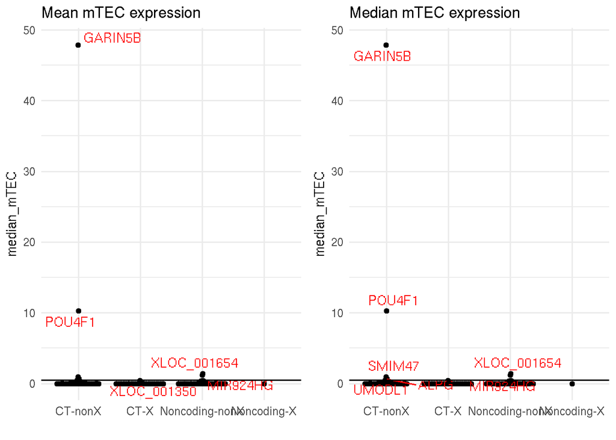

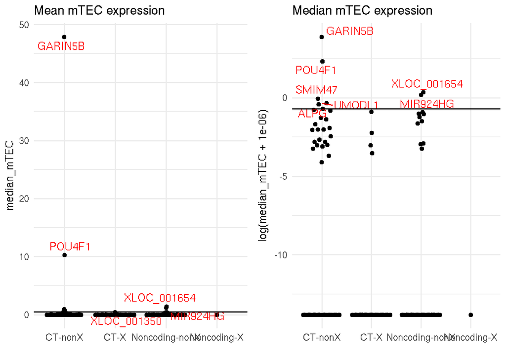

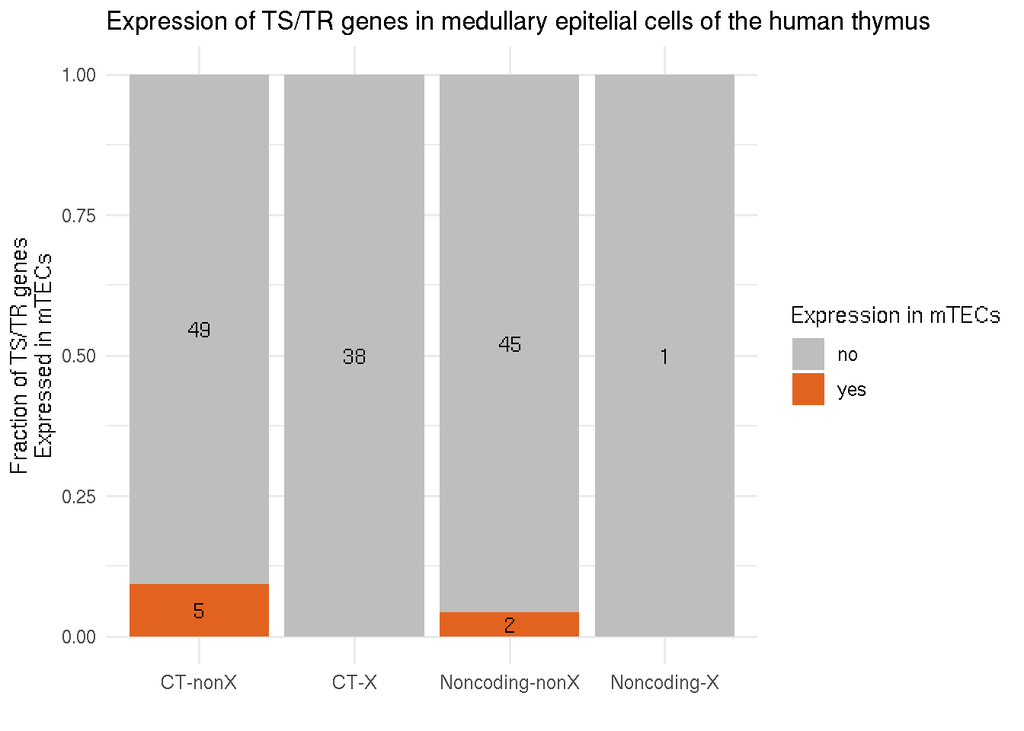

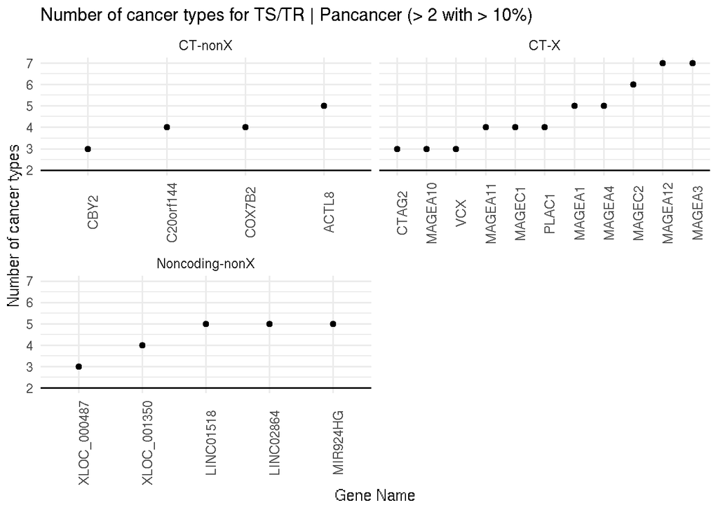

```
## [1] gene_name            total_n              coding_noncoding_chr
## [4] num_ctypes           Peptide_byPep        Source_byPep
## [7] Source_byGene
## <0 rows> (or 0-length row.names)
```

```
##       gene_name total_n coding_noncoding_chr num_ctypes Peptide_byPep
## 7     LINC01518      89       Noncoding-nonX          5          <NA>
## 8     LINC02864      98       Noncoding-nonX          5     CMAPGEILI
## 9     LINC02864      98       Noncoding-nonX          5     CMAPGEILI
## 101    MIR924HG      71       Noncoding-nonX          5          <NA>
## 104 XLOC_000487     188       Noncoding-nonX          3          <NA>
## 105 XLOC_001350      77       Noncoding-nonX          4          <NA>
##     Source_byPep Source_byGene
## 7           <NA>          <NA>
## 8        IEAtlas       IEAtlas
## 9        IEAtlas     CrypticDB
## 101         <NA>       IEAtlas
## 104         <NA>          <NA>
## 105         <NA>          <NA>
```

```
##     gene_name total_n coding_noncoding_chr num_ctypes Peptide_byPep
## 6       CTAG2      70                 CT-X          3          <NA>
## 10     MAGEA1     126                 CT-X          5    KEADPTGHSY
## 11     MAGEA1     126                 CT-X          5    KEADPTGHSY
## 12     MAGEA1     126                 CT-X          5    KEADPTGHSY
## 13     MAGEA1     126                 CT-X          5     ALREEEEGV
## 14     MAGEA1     126                 CT-X          5     ALREEEEGV
## 15     MAGEA1     126                 CT-X          5     ALREEEEGV
## 16     MAGEA1     126                 CT-X          5     SAYGEPRKL
## 17     MAGEA1     126                 CT-X          5     SAYGEPRKL
## 18     MAGEA1     126                 CT-X          5     SAYGEPRKL
## 19     MAGEA1     126                 CT-X          5     ALREEEEGV
## 20     MAGEA1     126                 CT-X          5     ALREEEEGV
## 21     MAGEA1     126                 CT-X          5     ALREEEEGV
## 22     MAGEA1     126                 CT-X          5     KVLEYVIKV
```

[output cut: 175 more lines]

```
##   gene_name total_n coding_noncoding_chr num_ctypes Peptide_byPep Source_byPep
## 1     ACTL8      97              CT-nonX          5          <NA>         <NA>
## 2 C20orf144      53              CT-nonX          4          <NA>         <NA>
## 3      CBY2      56              CT-nonX          3          <NA>         <NA>
## 4    COX7B2      91              CT-nonX          4    FHDKYGNAVL      IEAtlas
## 5    COX7B2      91              CT-nonX          4     FHDKYGNAV      IEAtlas
##   Source_byGene
## 1          <NA>
## 2          <NA>
## 3          <NA>
## 4          <NA>
## 5          <NA>
```

## CT-X // non-X

```
##
##        CT-nonX           CT-X Noncoding-nonX    Noncoding-X
##             54             38             47              1
```

```
##   ctype CT-nonX CT-X
## 1  BLCA      23   31
## 2  BRCA      14   12
## 3  COAD      14    7
## 4  KIRC       4   NA
## 5  LIHC      24   47
## 6  LUAD       8   12
## 7  LUSC      28   32
## 8  PRAD       1    9
```

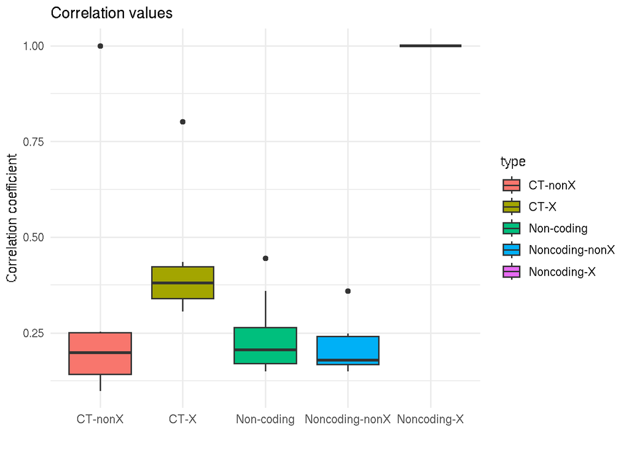

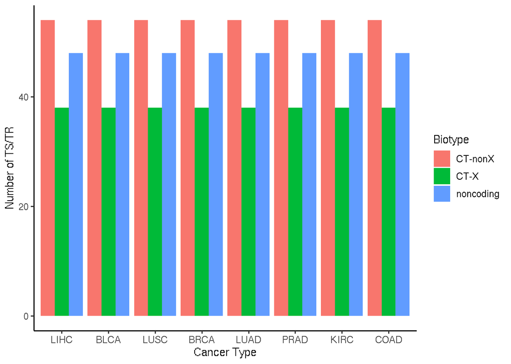

### How many MAGEA genes per ctype?